# House History

Charlotte Wickham

# Current Prototype

Working prototype at: https://cwickham.github.io/or-house-history/

**Idea**: Combine some views over time with a way to look at an individual year. Allows a general overview while being able to dig into specific years.

**Current problems:**

- Not dealing with split terms (currently the legislators sit on top of each other)
- Only using sessions after 1937. Why? From 1937 we have both 60 desks and 60 district numbers, which makes identifying vacancies and split terms easy.
- A little hard to select a particular year, and keep that selection while hovering over individual legislators.
- Need better popup tooltips when hovering over the time series (e.g. on majority plot, should read something like: “In 2009, Democrats were the majority party with a 10% lead”.)

## House in a particular session

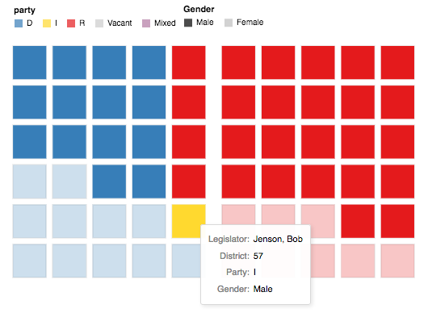

Advantages:

- Easily see which party has majority (e.g. do they travel over the 50% point), and a rough comparison of the proportion that are female.
- Each square represents a desk, so can provide legislator information on demand.

Disadvantages:

- Harder to deal with split terms (might visually split squares).
- While the layout is reminiscent of the house floor it isn’t exactly, and position doesn’t directly correspond to desk location.
- No way to easily find the history of a particular district/desk.

## Majority party over time

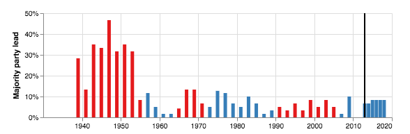

Advantages:

- Highlights the most important feature - who has the majority and by how much?
- Bars also highlight the changing frequency of regular sessions.

## Gender balance over time

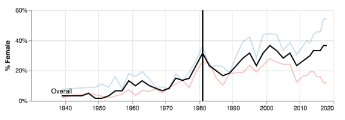

Advantages:

- Gives a good overview of trend over time for the whole house, as well as difference between two major parties.

Disadvantages:

- Need to think about future non-binary legislators, would “% not male” be more useful?
- Only shows two parties…other parties tend to be small so more variation in percentage (e.g. either 0% or 100%).

# Alternatives

Using the same general structure could swap out these particular views for other ones.

## House in a particular session

**A barchart**

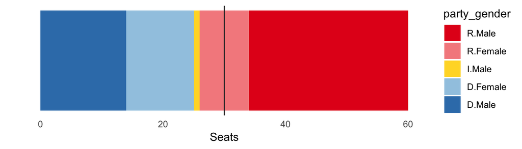

Advantages:

- Easy to see majority party
- Possible to see rough proportion of a party that is female.

Disadvantages:

- Hard to map to individual legislators
- Hard to see overall gender breakdown

**Side by side barcharts**

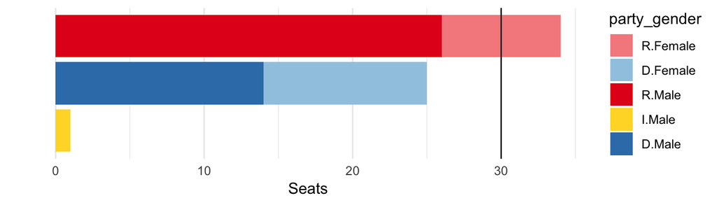

Advantages:

- Easy to see majority party
- Possible to see rough proportion of a party that is female.

Disadvantages:

- Hard to map to individual legislators
- Hard to see overall gender breakdown

**Semi-visual listing**

| Legislator | District | Party | Gender | party_gender |
| --- | --- | --- | --- | --- |
| Taylor, Jacqueline | 1 | D | Female | D.Female |
| Hopson, Elaine | 2 | D | Female | D.Female |
| Starr, Bruce | 3 | R | Male | R.Male |
| Thompson, Terry | 4 | D | Male | D.Male |
| Hill, Jim | 5 | R | Male | R.Male |
| Strobeck, Ken | 6 | R | Male | R.Male |
| Witt, Bill | 7 | R | Male | R.Male |
| Deckert, Ryan | 8 | D | Male | D.Male |
| Williams, Max | 9 | R | Male | R.Male |
| Snodgrass, Lynn | 10 | R | Female | R.Female |

[output cut: 50 more lines]

Advantages:

- Complete orderable listing of legislators makes it easy to look up a district, or see all names for a particular party/gender.

Disadvantages:

- Takes up a lot of space, doesn’t help with getting a quick idea of the breakdown by party or gender.

**Additional session level info displayed visually**

E.g. for 1999

| Republican | 34 seats | 24% female |
| --- | --- | --- |
| Democrat | 25 seats | 44% female |
| Independent | 1 seats | 0% female |

## Majority party over time

First over entire data (split terms probably aren’t counted right):

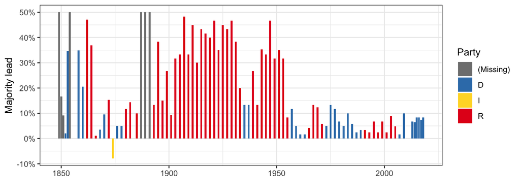

Variations on the current majority party plot

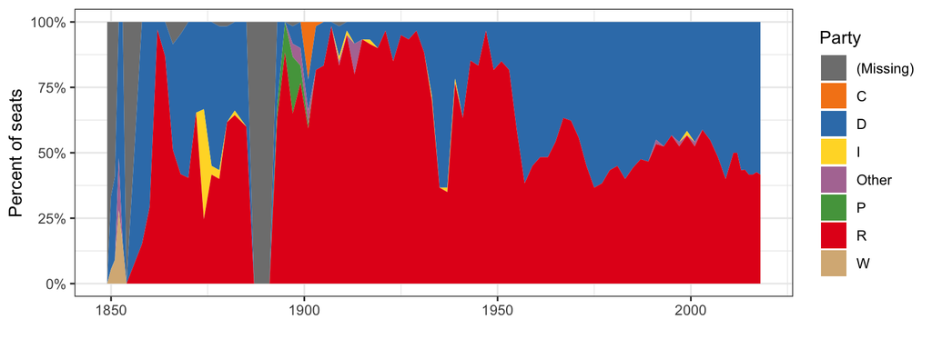

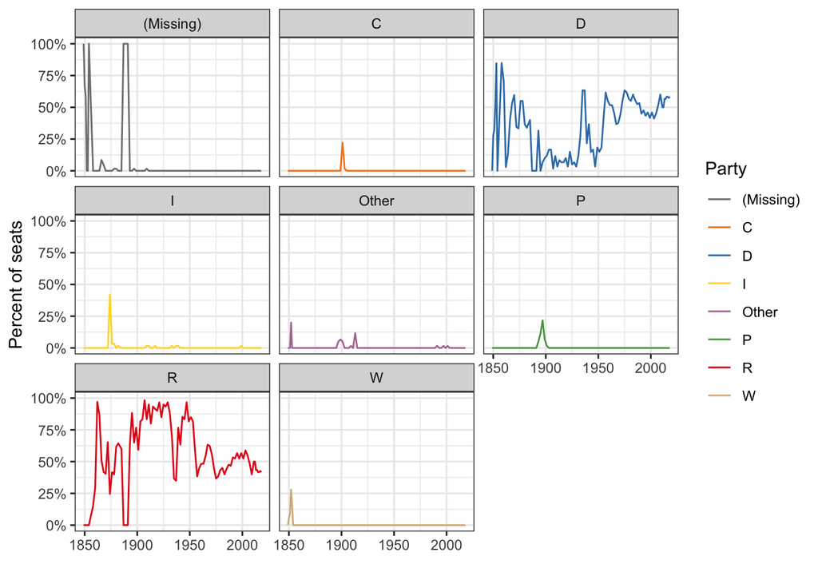

## Gender balance over time

First over longer time scale:

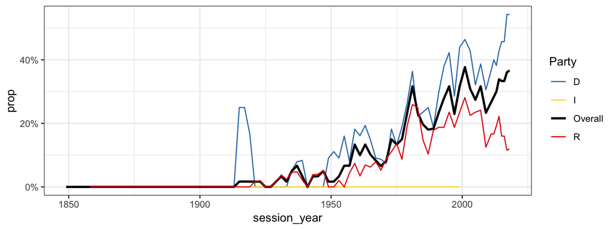

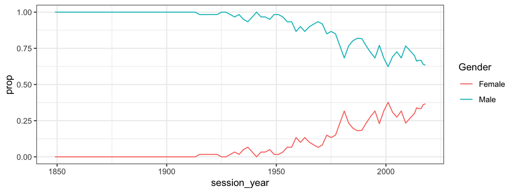

Not very useful since lines are just mirror images of eachother.

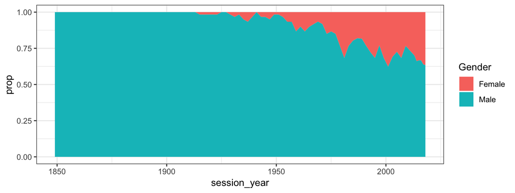

Also, not very useful, a lot of ink to tell only the story about the gender ratio for the house as a whole.